# Customer Satisfaction & Experience in Air Travel: A Comprehensive Data-Driven Study

# **Introduction**

**Why is customer satisfaction important in air travel?**

Customer satisfaction is a critical factor in the airline industry, influencing brand reputation, customer loyalty, and revenue. Understanding the factors that impact passenger experience can help airlines improve their services, leading to higher customer retention and better operational efficiency.

This study aims to analyze passenger satisfaction based on various factors such as service quality, demographics, flight characteristics, and travel behavior. Using data-driven insights, I aim to uncover key areas for improvement and provide recommendations for enhancing the overall travel experience.

### Problem Statement

**What challenge are we addressing?**

In the highly competitive airline industry, customer satisfaction is a key driver of business success. Airlines need to understand the factors influencing passenger experience, from service quality and demographics to travel behavior.

However, identifying the specific elements that impact satisfaction and addressing them effectively remains a challenge. This study aims to analyze customer feedback and service ratings to uncover insights that can enhance overall satisfaction, improve service quality, and optimize business strategies.

### Goal/Objectives

**What do we aim to achieve?**

1. **Analyze** overall customer satisfaction levels and their distribution.
2. **Examine** how different demographics (age, gender, customer type) impact satisfaction.
3. **Evaluate** the effect of travel-related factors (class, distance, delays) on customer experience.
4. **Identify** the key service aspects that drive satisfaction and dissatisfaction.
5. **Provide** actionable insights for airlines to enhance passenger experience and service quality.

## Dataset & Tools

### Dataset Source & Description

The dataset used for this analysis is sourced from [Maven Analytics](https://mavenanalytics.io/data-playground?page=6&pageSize=5).  
It contains detailed customer satisfaction feedback from airline passengers, covering various aspects of their travel experience.

#### Dataset Overview

The dataset includes the following key attributes:  
- **Passenger Information**: Customer type (First-time/Returning), travel type (Business/Personal), class (Economy/Business/Economy Plus).  
- **Service Ratings**: Ratings for check-in service, seat comfort, food & drink, cleanliness, inflight entertainment, baggage handling, etc.  
- **Flight Details**: Departure and arrival convenience, gate location, flight distance, delays.

This dataset provides a rich foundation for analyzing the key drivers of customer satisfaction and identifying areas for service improvement.

### Tools Used

To ensure a structured and efficient analysis, I utilized the following tools:  
**Excel** – Used for data cleaning and preparation:  
- Handled missing values and formatting inconsistencies. - Created calculated columns for additional insights.

**SQL** – Used for data analysis and querying:  
- Extracted key insights by aggregating and filtering data.  
- Performed calculations on service ratings, customer demographics, and flight details.  
- Segmented satisfaction levels based on various parameters.

Each tool played a crucial role in transforming raw data into meaningful business insights.

# **Key Visualizations & Insights**

To analyze passenger satisfaction, I used **SQL and R** to explore various aspects of customer feedback. The key areas analyzed include:

- **Overall Satisfaction Analysis**
- **Customer Demographics & Satisfaction**
- **Service Ratings & Key Factors**
- **Age & Satisfaction**
- **Gender & Satisfaction**
- **Flight Distance & Satisfaction**
- **Flight Delays & Customer Satisfaction**

#### **Load Required Libraries and Explore the Data**

**• To begin the analysis, I installed and loaded the necessary libraries for data manipulation and visualization.**

```r
library(ggplot2)
library(dplyr)
library(tidyr)
library(forcats)
library(readr)
library(readxl)
```

**• Imported the airline passenger satisfaction dataset into R for analysis.**

**• Dataset Overview:** The dataset consists of attributes related to passenger demographics, flight details, and service ratings. Below is a sample preview:

```r
head(airline_passenger_satisfaction)
```

|  | id | gender | age | customer_type | type_of_travel | class | flight_distance | departure_delay | arrival_delay | departure_and_arrival_time_convenience | ease_of_online_booking | check_in_service | online_boarding | gate_location | on_board_service | seat_comfort | leg_room_service | cleanliness | food_and_drink | in_flight_service | in_flight_wifi_service | in_flight_entertainment | baggage_handling | satisfaction | total_satisfaction_level |
| --- | --- | --- | --- | --- | --- | --- | --- | --- | --- | --- | --- | --- | --- | --- | --- | --- | --- | --- | --- | --- | --- | --- | --- | --- | --- |
| 1 | 1 | Male | 48 | First-time | Business | Business | 821 | 2 | 5 | 3 | 3 | 4 | 3 | 3 | 3 | 5 | 2 | 5 | 5 | 5 | 3 | 5 | 5 | Neutral or Dissatisfied | 0 |
| 2 | 2 | Female | 35 | Returning | Business | Business | 821 | 26 | 39 | 2 | 2 | 3 | 5 | 2 | 5 | 4 | 5 | 5 | 3 | 5 | 2 | 5 | 5 | Satisfied | 1 |
| 3 | 3 | Male | 41 | Returning | Business | Business | 853 | 0 | 0 | 4 | 4 | 4 | 5 | 4 | 3 | 5 | 3 | 5 | 5 | 3 | 4 | 3 | 3 | Satisfied | 1 |
| 4 | 4 | Male | 50 | Returning | Business | Business | 1905 | 0 | 0 | 2 | 2 | 3 | 4 | 2 | 5 | 5 | 5 | 4 | 4 | 5 | 2 | 5 | 5 | Satisfied | 1 |
| 5 | 5 | Female | 49 | Returning | Business | Business | 3470 | 0 | 1 | 3 | 3 | 3 | 5 | 3 | 3 | 4 | 4 | 5 | 4 | 3 | 3 | 3 | 3 | Satisfied | 1 |
| 6 | 6 | Male | 43 | Returning | Business | Business | 3788 | 0 | 0 | 4 | 4 | 3 | 5 | 4 | 4 | 4 | 4 | 3 | 3 | 4 | 4 | 4 | 4 | Satisfied | 1 |

## Overall Customer Satisfaction Analysis

**How satisfied are customers overall, and what percentage of them report high satisfaction?Is there a significant portion of dissatisfied customers that need attention?**

When analyzing airline customer satisfaction, I began by exploring how passengers feel about their overall experience. To do this, I first examined the distribution of customer sentiment using both a bar chart and a pie chart, each offering a different perspective on the data.

A grouped summary is created using R and SQL to count customers in each category. This structured data is then visualized to identify key trends.

```r
satisfaction_counts <- airline_passenger_satisfaction %>%
  group_by(satisfaction) %>%
  summarise(count = n(), .groups = "drop") %>%
  mutate(percentage = round((count / sum(count)) * 100, 2)) %>%
  arrange(desc(count))  # Descending order mein sort karna

# Print output
print(satisfaction_counts)
```

| satisfaction | count | percentage |
| --- | --- | --- |
| Neutral or Dissatisfied | 73452 | 56.55 |
| Satisfied | 56428 | 43.45 |

```r
NA
```

**A pie chart is generated to display satisfaction distribution in percentage terms. This provides a clear proportional view of customer sentiment.**

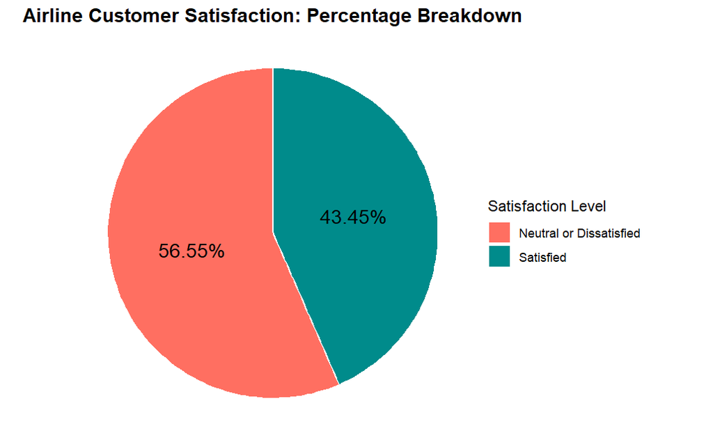

```r
ggplot(satisfaction_counts, aes(x = "", y = count, fill = satisfaction)) +
  geom_bar(stat = "identity", width = 1, color = "white") +
  coord_polar(theta = "y") +
  geom_text(aes(label = paste0(percentage, "%")),
            position = position_stack(vjust = 0.5), size = 5, color = "black") +
  scale_fill_manual(values = c("Neutral or Dissatisfied" = "#FF6F61",
                               "Satisfied" = "#008B8B")) +
   labs(title = "Airline Customer Satisfaction: Percentage Breakdown",
       fill = "Satisfaction Level") +
  theme_void() +
  theme(plot.title = element_text(hjust = 0.5, size = 14, face = "bold"))
```

**Key Insights:**

A different representation focuses on the customer distribution of satisfaction levels. From this, we see:

● **Only 43.45% of customers** report high satisfaction, while the remaining 56.55% fall into the neutral or dissatisfied category.

● **This breakdown confirms** that a majority of customers are not fully satisfied, highlighting a potential risk to customer retention.

● **The proportion-based approach** is particularly useful for decision-makers, as it provides a clear view of whether customer sentiment is leaning positively or negatively.

**This chart is generated to compare the number of satisfied and dissatisfied customers. The visualization provides an absolute count for each category.**

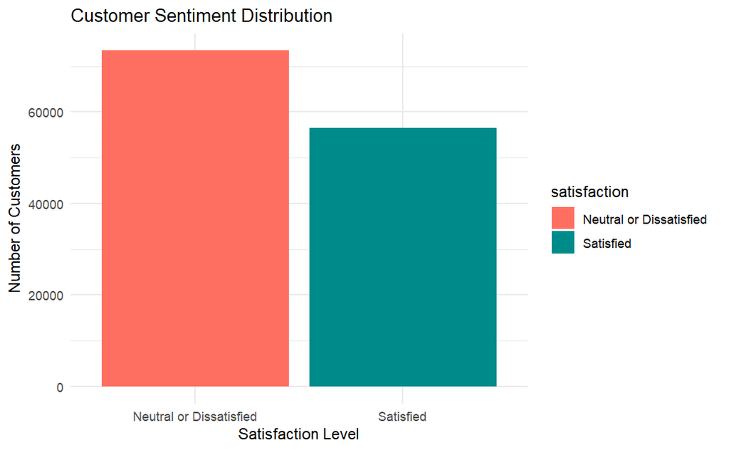

```r
# Summarize Data: Equivalent to SQL Query
satisfaction_summary <- airline_passenger_satisfaction %>%
  group_by(satisfaction) %>%
  summarise(
    total_customers = n()
  )

# Define custom colors
satisfaction_colors <- c("Satisfied" = "#008B8B", "Neutral or Dissatisfied" = "#FF6F61")

# Create Bar Chart
ggplot(satisfaction_summary, aes(x = satisfaction, y = total_customers, fill = satisfaction)) +
  geom_bar(stat = "identity") +
  scale_fill_manual(values = satisfaction_colors) +  # Apply custom colors
  labs(
    title = "Customer Sentiment Distribution",
    x = "Satisfaction Level",
    y = "Number of Customers"
  ) +
  theme_minimal()  # Use minimal theme for clean look
```

**Key Insights:**

● **The Neutral or Dissatisfied category** has a higher count than Satisfied customers.

● **This suggests** a higher proportion of customers are not reporting a positive experience, indicating areas that need improvement.

## Customer Demographics & Satisfaction

Understanding customer demographics is essential for identifying patterns in satisfaction levels. This analysis focuses on three key aspects including Customer Type, Travel Type and Travel Class. Each factor plays a significant role in shaping customer experience and influencing service improvement strategies.

### Returning vs. First-Time Passenger

**Are Returning customers more satisfied than First_time customers?**

```r
customer_satisfaction_summary <- airline_passenger_satisfaction %>%
  group_by(customer_type, satisfaction) %>%
  summarise(count = n(), .groups = 'drop') %>%
  group_by(customer_type) %>%
  mutate(percentage = round((count / sum(count)) * 100, 2)) %>%
  ungroup() %>%
  arrange(customer_type, desc(percentage))  # Sort like SQL


# Print result to check output
print(customer_satisfaction_summary)
```

| customer_type | satisfaction | count | percentage |
| --- | --- | --- | --- |
| First-time | Neutral or Dissatisfied | 18080 | 76.03 |
| First-time | Satisfied | 5700 | 23.97 |
| Returning | Neutral or Dissatisfied | 55372 | 52.19 |
| Returning | Satisfied | 50728 | 47.81 |

To analyze whether returning customers are more satisfied than first-time customers, I examined the distribution of satisfaction levels among both groups. The dataset was grouped by customer type and satisfaction level, and the percentage of satisfied and dissatisfied customers was calculated for each group.

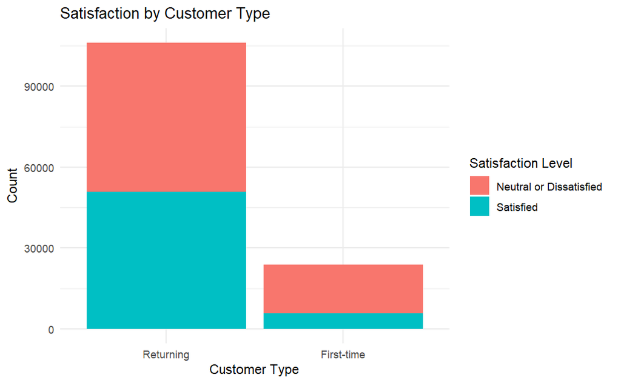

```r
ggplot(customer_satisfaction_summary,
       aes(x = fct_reorder(customer_type, -count), y = count, fill = satisfaction)) +
  geom_bar(stat = "identity", position = "stack") +
  labs(title = "Satisfaction by Customer Type",
       x = "Customer Type",
       y = "Count",
       fill = "Satisfaction Level") +
  theme_minimal()
```

**Key Insights:**

● **Returning customers have a higher satisfaction rate**, as seen in the larger proportion of satisfied customers compared to first-time travelers.

● **The difference suggests** that returning customers may have better expectations, familiarity with the service, or loyalty program benefits, leading to higher satisfaction.

**Key Takeaways:**

Returning customers are more satisfied than first-time customers. This means new travelers may face difficulties or have unmet expectations. Airlines should focus on making first-time travel easier and more comfortable by improving guidance, check-in experience, and personalized services.

### Business vs. Personal Passenger

**Do Business Travelers Have Higher Satisfaction Compared to Personal Travelers?**

Understanding traveler satisfaction based on the type of travel (Business vs. Personal) helps in identifying service gaps and improving the overall travel experience.

```r
travel_satisfaction <- airline_passenger_satisfaction %>%
  group_by(type_of_travel, satisfaction) %>%
  summarise(count = n(), .groups = "drop")
print(travel_satisfaction)
```

| type_of_travel | satisfaction | count |
| --- | --- | --- |
| Business | Neutral or Dissatisfied | 37337 |
| Business | Satisfied | 52356 |
| Personal | Neutral or Dissatisfied | 36115 |
| Personal | Satisfied | 4072 |

```r
NA
NA
```

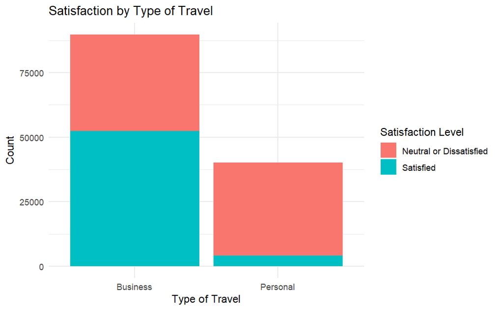

```r
ggplot(travel_satisfaction,
       aes(x = fct_reorder(type_of_travel, -count),  # Order by count
           y = count,
           fill = satisfaction)) +
  geom_bar(stat = "identity", position = "stack") +  # Stacked bars
  labs(title = "Satisfaction by Type of Travel",
       x = "Type of Travel",
       y = "Count",
       fill = "Satisfaction Level") +
  theme_minimal()
```

**Key Insights:**

● Business travelers generally report better satisfaction, possibly due to premium services, corporate travel perks, or structured itineraries.

● Personal travelers show low satisfaction, highlighting a need for enhanced services, better pricing, or improved travel experiences in leisure travel.  
**Key Takeaways:**

Business travelers are much more satisfied than personal travelers. This suggests that airlines are meeting the needs of business travelers well, but personal travelers (leisure travelers) may not have the same comfort. To improve satisfaction, airlines should enhance the experience for leisure travelers by offering better seats, entertainment, and affordable add-ons.

### Airline Passenger Satisfaction by Travel Class

The goal of this analysis is to determine which travel class (Economy, Business, Economy Plus) has the highest and lowest passenger satisfaction levels.

```r
satisfaction_class <- airline_passenger_satisfaction %>%
 group_by(class, satisfaction) %>%
  summarise(count = n(), .groups = 'drop') %>%
  group_by(class) %>%
  mutate(percentage = round(count * 100 / sum(count), 2)) %>%
  arrange(class, desc(percentage))  # Order by class and percentage descending

# Print result
print(satisfaction_class)
```

| class | satisfaction | count | percentage |
| --- | --- | --- | --- |
| Business | Satisfied | 43166 | 69.44 |
| Business | Neutral or Dissatisfied | 18994 | 30.56 |
| Economy | Neutral or Dissatisfied | 47366 | 81.23 |
| Economy | Satisfied | 10943 | 18.77 |
| Economy Plus | Neutral or Dissatisfied | 7092 | 75.36 |
| Economy Plus | Satisfied | 2319 | 24.64 |

```r
NA
NA
NA
```

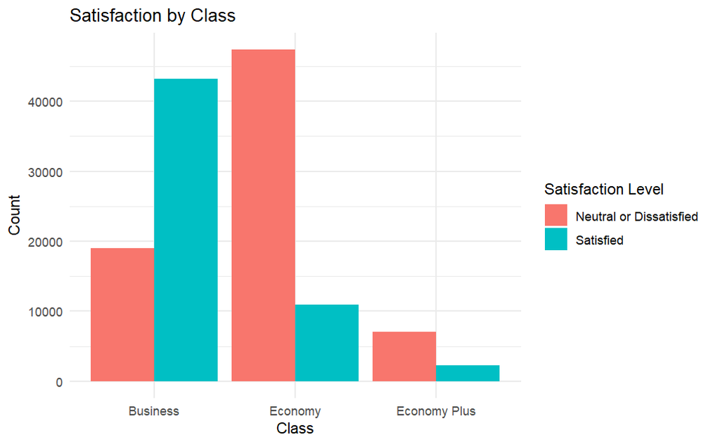

```r
ggplot(airline_passenger_satisfaction,
       aes(x = fct_reorder(class, -table(class)[class]), fill = satisfaction)) +
  geom_bar(position = "dodge") +  # Side-by-side bars instead of stacked
  labs(title = "Satisfaction by Class",
       x = "Class",
       y = "Count",
       fill = "Satisfaction Level") +
  theme_minimal()
```

**Key Insights:**

● **Business Class** has the highest satisfaction rate at 69.44%, indicating that premium services contribute to a positive customer experience.

● **Economy Class** shows the highest dissatisfaction rate, with 81.23% of passengers being neutral or dissatisfied, highlighting potential service quality issues.

● **Economy Plus** is slightly better than Economy but still faces challenges, with 75.36% of passengers dissatisfied, suggesting a need for stronger differentiation.

**Key Takeaways:**

This analysis highlights how travel class directly impacts passenger satisfaction. Improving services in Economy and Economy Plus could enhance overall customer experience and brand loyalty for airlines.

**However, to understand why these differences exist, I analyzed key service factors that influence satisfaction in each class.**

## Service Ratings & Key Factors

**Which service aspects (cleanliness, staff, food, etc.) have the highest impact on customer satisfaction? Are there any major weaknesses in the service that require immediate improvement?**

To identify key service aspects (cleanliness, staff, food, etc.) that most impact customer satisfaction and highlight critical weaknesses requiring immediate improvement.

```r
# Dataframe with SQL Result Data
df <- data.frame(
  service = c("in_flight_service", "baggage_handling", "seat_comfort",
              "on_board_service", "in_flight_entertainment", "leg_room_service",
              "check_in_service", "cleanliness", "online_boarding",
              "food_and_drink", "departure_and_arrival_time_convenience",
              "gate_location", "ease_of_online_booking", "in_flight_wifi_service"),

  avg_rating = c(3.642192793, 3.632114259, 3.441361257,
                 3.38302279, 3.358076686, 3.350877733,
                 3.306267324, 3.286325839, 3.2526332,
                 3.204773637, 3.057599322, 2.976924854,
                 2.756875577, 2.728695719)
)

# Select Top 3 and Lowest 3 Factors
top_factors <- df %>% arrange(desc(avg_rating)) %>% head(3)
low_factors <- df %>% arrange(avg_rating) %>% head(3)
print(df)
```

| service | avg_rating |
| --- | --- |
| in_flight_service | 3.642193 |
| baggage_handling | 3.632114 |
| seat_comfort | 3.441361 |
| on_board_service | 3.383023 |
| in_flight_entertainment | 3.358077 |
| leg_room_service | 3.350878 |
| check_in_service | 3.306267 |
| cleanliness | 3.286326 |
| online_boarding | 3.252633 |
| food_and_drink | 3.204774 |

[output cut: 4 more lines]

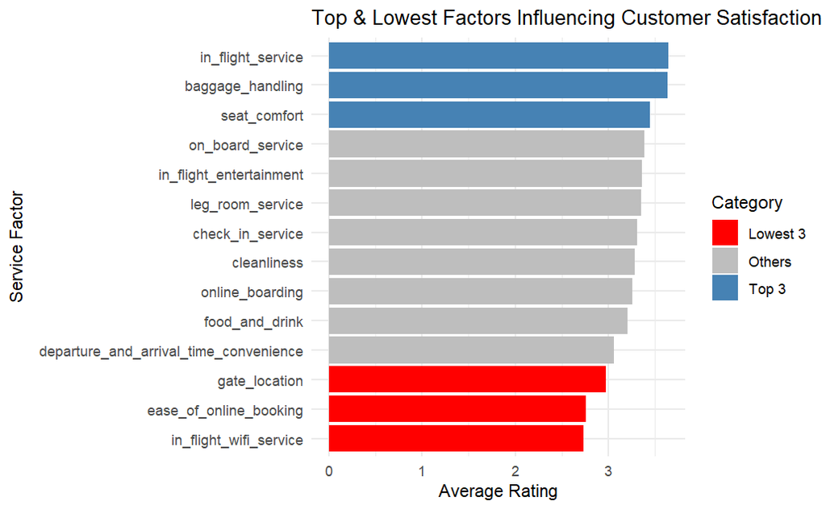

```r
# Plot with Highlights
ggplot(df, aes(x = reorder(service, avg_rating), y = avg_rating,
               fill = case_when(
                 service %in% top_factors$service ~ "Top 3",
                 service %in% low_factors$service ~ "Lowest 3",
                 TRUE ~ "Others"
               ))) +
  geom_bar(stat = "identity", show.legend = TRUE) +  # Bar Chart
  scale_fill_manual(values = c("Top 3" = "steelblue",
                               "Lowest 3" = "red",
                               "Others" = "grey")) +  # Different Colors
  coord_flip() +  # Flip for better readability
  labs(title = "Top & Lowest Factors Influencing Customer Satisfaction",
       x = "Service Factor",
       y = "Average Rating",
       fill = "Category") +  # Legend
  theme_minimal()
```

### Key Factors Impacting Customer Satisfaction:

From the analysis, the top three service aspects that have the highest positive impact on customer satisfaction are:

● **In-flight service** – Passengers value attentive and friendly cabin crew who enhance their travel experience.

● **Baggage handling** – Efficient luggage management ensures a smooth journey without delays or lost baggage.

● **Seat comfort** – Comfortable seating is crucial, especially for long-haul flights, making it a key factor in satisfaction.

**Insight:** Airlines should continue to prioritize these areas to maintain high satisfaction levels.

### Major Weaknesses Requiring Immediate Improvement:

On the other hand, the three weakest service factors that negatively impact customer satisfaction are:

● **Poor in-flight WiFi** – Slow and unreliable, failing passenger expectations.  
● **Complicated booking** – Difficult processes lead to frustration and lost customers.  
● **Inconvenient gate locations** – Long walks and poor accessibility reduce comfort.

**Key Takeaways: Actionable Steps for Improvement:**

● Enhance WiFi quality to meet modern passenger expectations.

● Simplify the online booking experience with a user-friendly interface.

● Optimize gate locations and provide better navigation assistance within airports.

### Service Ratings & Key Factors by Class Type

**Are there any significant gaps in ratings between Business, Economy Plus, and Economy classes?**

This analysis examines service ratings across different travel classes (Business, Economy Plus, and Economy) to identify key trends and areas for improvement.

```r
# Calculate Average Ratings by Class
ratings_avg <- airline_passenger_satisfaction %>%
  group_by(class) %>%
  summarise(
    Seat_Comfort = mean(seat_comfort, na.rm = TRUE),
    Legroom_Service = mean(leg_room_service, na.rm = TRUE),
    Onboard_Service = mean(on_board_service, na.rm = TRUE),
    Food_Drink = mean(food_and_drink, na.rm = TRUE),
    Entertainment_Wifi = mean(in_flight_entertainment, na.rm = TRUE),
    Cleanliness = mean(cleanliness, na.rm = TRUE),
    Baggage_Handling = mean(baggage_handling, na.rm = TRUE)
  ) %>%
  arrange(factor(class, levels = c("Business", "Economy Plus", "Economy")))  # Ensure correct ordering

# Print Summary
print(ratings_avg)
```

| class | Seat_Comfort | Legroom_Service | Onboard_Service | Food_Drink | Entertainment_Wifi | Cleanliness | Baggage_Handling |
| --- | --- | --- | --- | --- | --- | --- | --- |
| Business | 3.763707 | 3.646042 | 3.682529 | 3.329955 | 3.639350 | 3.481998 | 3.844852 |
| Economy Plus | 3.168207 | 3.056211 | 3.036234 | 3.110403 | 3.120497 | 3.118478 | 3.351504 |
| Economy | 3.141813 | 3.083778 | 3.119707 | 3.086556 | 3.096572 | 3.104821 | 3.450617 |

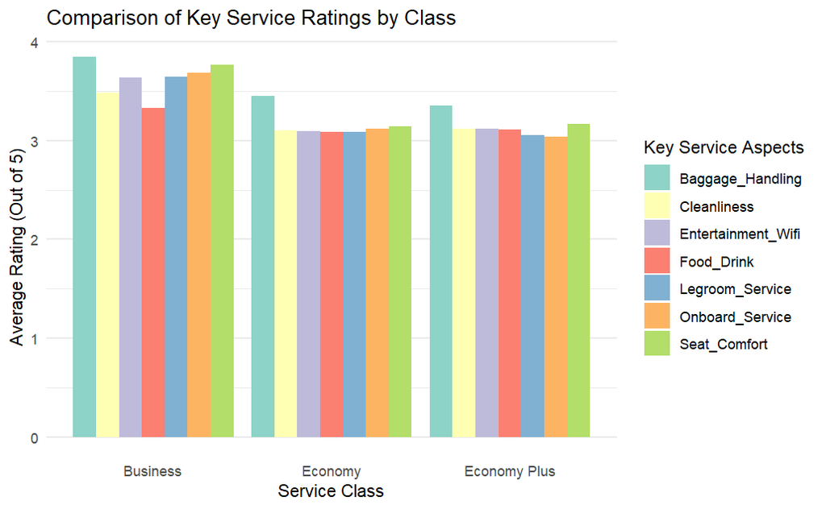

```r
# Convert ONLY the required key factors to long format
ratings_long <- ratings_avg %>%
  pivot_longer(cols = c(Seat_Comfort, Legroom_Service, Onboard_Service,
                        Food_Drink, Entertainment_Wifi, Cleanliness, Baggage_Handling),
               names_to = "Service_Aspect", values_to = "Average_Rating")

# Plot
ggplot(ratings_long, aes(x = class, y = Average_Rating, fill = Service_Aspect)) +
  geom_bar(stat = "identity", position = "dodge") +
  theme_minimal() +
  scale_fill_brewer(palette = "Set3") +  # Ensures distinct colors for each aspect
  labs(title = "Comparison of Key Service Ratings by Class",
       x = "Service Class", y = "Average Rating (Out of 5)",
       fill = "Key Service Aspects") +
  theme(axis.text.x = element_text(angle = 0, hjust = 0.5),
        legend.position = "right",
        panel.grid.major.x = element_blank())  # Removes vertical grid lines
```

**Key Insights:**

• **Business Class:**  
- Best-rated service aspects: **Seat Comfort (3.76), Baggage Handling (3.84)**  
- Lowest-rated service: **Food & Drink (3.32)**  
- Despite higher ratings, **Food & Drink is the weakest point**, suggesting scope for menu enhancement.

**Key Takeaways:**

• **Enhance Food & Drink quality** in all classes by introducing **healthier options & premium meal upgrades**.  
• **Improve seat comfort** in Economy & Economy Plus through **better padding & adjustable features**.  
• **Upgrade in-flight entertainment & WiFi**, especially for Economy passengers.

## Age & Customer Satisfaction

**Which age group reports the highest and lowest satisfaction?Are there specific trends in satisfaction levels across age categories?What factors might be contributing to lower ratings for certain age groups?**

This analysis aims to understand how passenger satisfaction varies across different age groups and identify which demographics are the most satisfied or dissatisfied.

```r
df_age_rating <- airline_passenger_satisfaction %>%
  mutate(age_group = case_when(
    age < 18 ~ "Under 18",
    age >= 18 & age < 30 ~ "18-29",
    age >= 30 & age < 45 ~ "30-44",
    age >= 45 & age < 60 ~ "45-59",
    age >= 60 ~ "60+"
  )) %>%
  group_by(age_group) %>%
  summarise(avg_rating = mean(total_satisfaction_level, na.rm = TRUE), .groups = "drop") %>%
  arrange(desc(avg_rating))  # Descending order mein sort karna

# Print output
print(df_age_rating)
```

| age_group | avg_rating |
| --- | --- |
| 45-59 | 0.5753099 |
| 30-44 | 0.4757208 |
| 18-29 | 0.3485901 |
| 60+ | 0.2706508 |
| Under 18 | 0.1672591 |

```r
NA
```

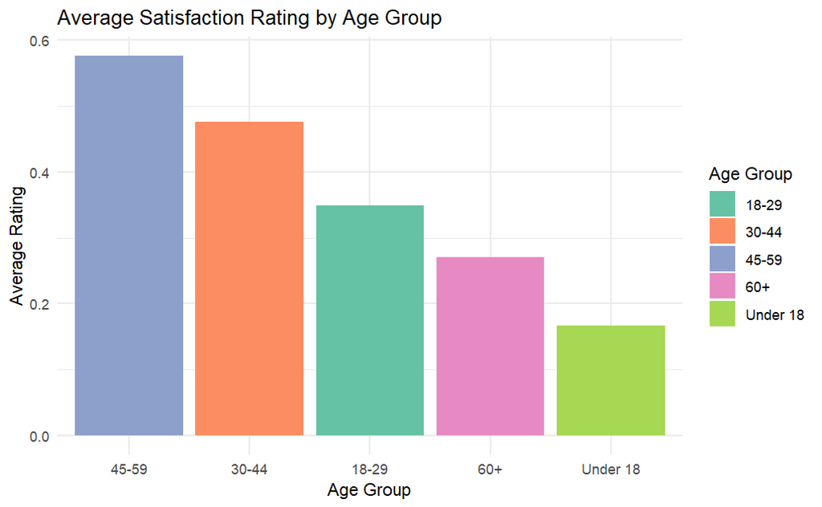

```r
ggplot(df_age_rating, aes(x = reorder(age_group, -avg_rating), y = avg_rating, fill = age_group)) +
  geom_bar(stat = "identity") +
  labs(title = "Average Satisfaction Rating by Age Group",
       x = "Age Group",
       y = "Average Rating",
       fill = "Age Group") +
  theme_minimal() +
  scale_fill_brewer(palette = "Set2")
```

**Key Insights:**

• **Highest Satisfaction:** The **45-59** age group reports the highest satisfaction levels.  
• **Moderate Satisfaction:** The **30-44** and **18-29** age groups have moderate satisfaction, with **30-44** rating higher.  
• **Lowest Satisfaction:** The **Under 18** and **60+** age groups report the lowest satisfaction, indicating potential concerns.

**Key Takeaways:**

• **Enhance Accessibility for Seniors:** Address comfort and assistance needs for the **60+** group.  
• **Maintain High Standards:** Keep service quality high for the **45-59** age group while ensuring continuous improvement.

## Gender-Based Customer Satisfaction Analysis

**Do male and female customers perceive satisfaction differently?**

To conduct a data-driven analysis of gender-based customer satisfaction, identifying any significant differences in how male and female customers perceive service quality and overall experience.

```r
df_gender <- airline_passenger_satisfaction %>%
  group_by(gender, satisfaction) %>%
  summarise(count = n(), .groups = "drop") %>%
  mutate(percentage = round(count * 100 / sum(count), 2), .by = gender)  # Partition by gender

print(df_gender)
```

| gender | satisfaction | count | percentage |
| --- | --- | --- | --- |
| Female | Neutral or Dissatisfied | 37630 | 57.10 |
| Female | Satisfied | 28269 | 42.90 |
| Male | Neutral or Dissatisfied | 35822 | 55.99 |
| Male | Satisfied | 28159 | 44.01 |

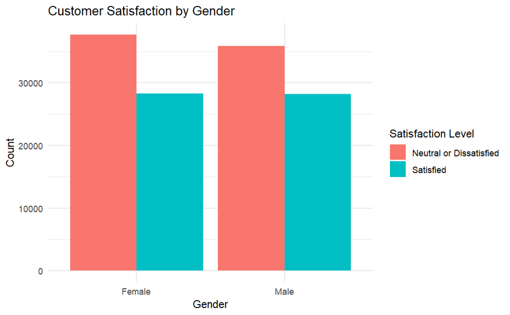

```r
# Create the grouped bar chart
ggplot(df_gender, aes(x = gender, y = count, fill = satisfaction)) +
  geom_bar(stat = "identity", position = "dodge") +  # 'dodge' for side-by-side bars
  labs(title = "Customer Satisfaction by Gender",
       x = "Gender",
       y = "Count",
       fill = "Satisfaction Level") +
  theme_minimal()
```

**Key Insights:**

**Overall Satisfaction Levels:**  
• **Male customers report slightly higher satisfaction (44.01%)** compared to **female customers (42.90%)**.  
• A **larger portion of customers remain neutral or dissatisfied**, with **female customers showing a marginally higher dissatisfaction rate (57.10%) vs. 55.99% for males**.

**Gender-Based Differences:**  
• The **1.11% gap in satisfaction between genders** is minimal, indicating that **gender alone is not a key driver of satisfaction**.  
• **Other influencing factors, such as service quality, Food & Drink, Inconvenient gate locations,WiFi and accessibility, should be explored** for deeper insights.

**Key Takeaways:**

• **Satisfaction levels between genders are nearly identical**, so gender-specific strategies may not be necessary.  
• **Improvements should focus on universal service enhancements** rather than gender-driven adjustments.  
• **Further segmentation analysis** (e.g., Distance and Delays) could reveal stronger trends affecting satisfaction.

## Customer Satisfaction Analysis: The Impact of Travel Distance

**Is there Relationship Between Distance and Satisfaction?Does travel distance affect passenger satisfaction, and if so, why are long-distance travelers more satisfied than short-distance travelers?**

The goal of this study is to understand how travel distance impacts customer satisfaction and to identify key factors that contribute to this difference.

### Initial Observation: Satisfaction Trends in Travel Distance

```r
# Data from SQL findings
satisfaction_data <- data.frame(
  satisfaction = c("Neutral or Dissatisfied", "Satisfied"),
  avg_distance = c(929.7154, 1529.5392)
)

# Print the data frame
print(satisfaction_data)
```

| satisfaction | avg_distance |
| --- | --- |
| Neutral or Dissatisfied | 929.7154 |
| Satisfied | 1529.5392 |

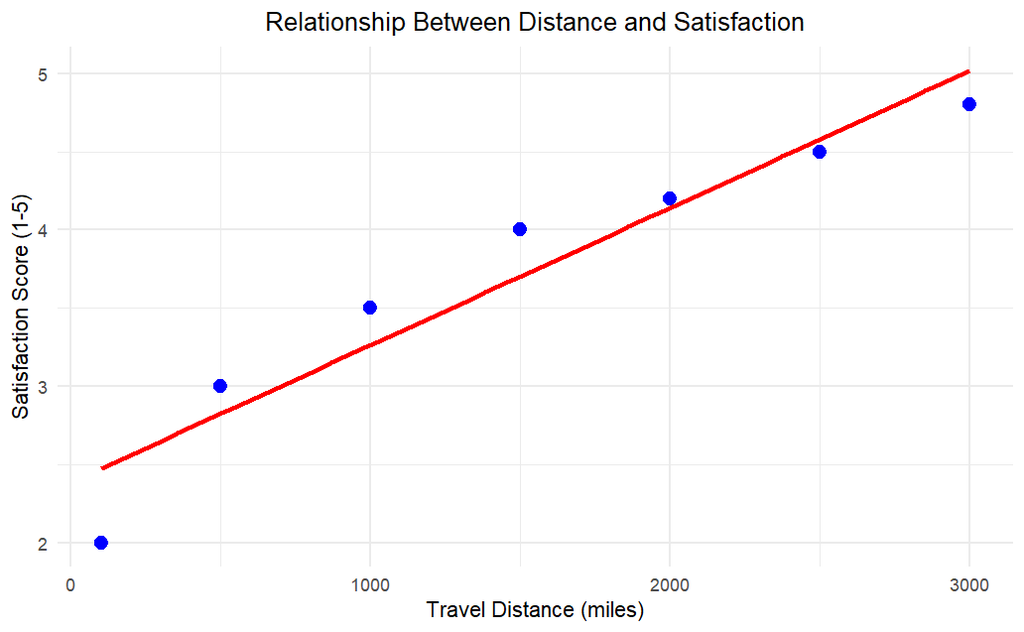

```r
# Data from SQL Findings
satisfaction_data <- data.frame(
  Distance = c(100, 500, 1000, 1500, 2000, 2500, 3000),
  Satisfaction_Score = c(2, 3, 3.5, 4, 4.2, 4.5, 4.8)  # Example scores
)

# Scatter plot
ggplot(satisfaction_data, aes(x = Distance, y = Satisfaction_Score)) +
  geom_point(color = "blue", size = 3) +
  geom_smooth(method = "lm", color = "red", se = FALSE) +  # Linear trend line
  theme_minimal() +
  labs(title = "Relationship Between Distance and Satisfaction",
       x = "Travel Distance (miles)",
       y = "Satisfaction Score (1-5)") +
  theme(plot.title = element_text(hjust = 0.5))
```

**Key Insights:**

• **Satisfaction increases with travel distance**, indicating a positive correlation.  
• **A clear gap exists** between short and long-haul passengers, suggesting distance impacts perceived service quality.

**Why are long-distance travelers more satisfied?**Further analysis needed to identify key contributing factors

### Service Factor Comparison: Long vs. Short Distance

**To compare customer satisfaction between long-distance and short-distance travelers, identifying key factors that contribute to higher satisfaction among long-distance travelers through data-driven analysis.**

```r
 # Create a dataframe with SQL results
data <- data.frame(
  Factor = c("Departure Convenience", "Online Booking", "Check-in Service", "Online Boarding", "Gate Location",
             "Onboard Service", "Seat Comfort", "Legroom", "Cleanliness", "Food & Drink",
             "In-flight Service", "WiFi Service", "Entertainment", "Baggage Handling"),
  Long_Distance = c(3.065, 2.830, 3.387, 3.458, 2.977, 3.491, 3.591, 3.480, 3.379, 3.260,
                    3.703, 2.740, 3.475, 3.690),
  Short_Distance = c(3.050, 2.684, 3.226, 3.046, 2.977, 3.275, 3.292, 3.222, 3.194, 3.149,
                     3.581, 2.718, 3.241, 3.574)
)

# Sort the data in descending order based on Long_Distance ratings
data_sorted_long <- data %>% arrange(desc(Long_Distance))

# Sort the data in descending order based on Short_Distance ratings
data_sorted_short <- data %>% arrange(desc(Short_Distance))

# Print the sorted data
print(data_sorted_short)  # Sorted by Short_Distance Ratings
```

| Factor | Long_Distance | Short_Distance |
| --- | --- | --- |
| In-flight Service | 3.703 | 3.581 |
| Baggage Handling | 3.690 | 3.574 |
| Seat Comfort | 3.591 | 3.292 |
| Onboard Service | 3.491 | 3.275 |
| Entertainment | 3.475 | 3.241 |
| Check-in Service | 3.387 | 3.226 |
| Legroom | 3.480 | 3.222 |
| Cleanliness | 3.379 | 3.194 |
| Food & Drink | 3.260 | 3.149 |
| Departure Convenience | 3.065 | 3.050 |

[output cut: 4 more lines]

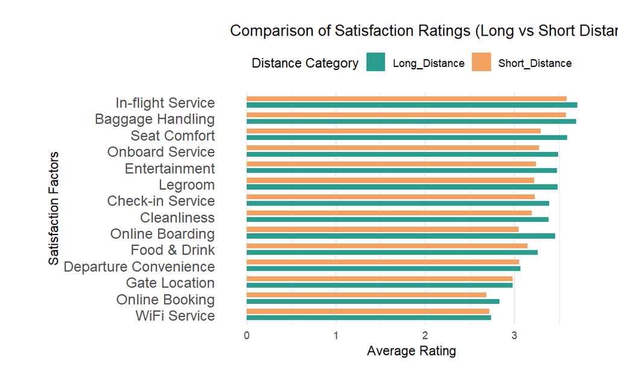

```r
# Plot Grouped Bar Chart with softer colors
ggplot(data_long, aes(x = reorder(Factor, Rating), y = Rating, fill = Distance_Category)) +
  geom_bar(stat = "identity", position = position_dodge(width = 0.8), width = 0.6) +  # Adjust bar width
  scale_fill_manual(values = c("Long_Distance" = "#2A9D8F", "Short_Distance" = "#F4A261")) +  # Softer colors
  theme_minimal() +
  coord_flip() +  # Flip for better readability
  labs(title = "Comparison of Satisfaction Ratings (Long vs Short Distance)",
       x = "Satisfaction Factors",
       y = "Average Rating",
       fill = "Distance Category") +
  theme(
    axis.text.y = element_text(size = 12, margin = margin(r = 10)),  # Add spacing between labels
    legend.position = "top",
    panel.grid.major.y = element_blank(),  # Remove extra grid lines for clarity
    plot.margin = margin(20, 20, 20, 40)  # Add padding around the plot
  )
```

**Key Insights:**

***Satisfaction Trends:**  
• Long-distance travelers report **higher satisfaction** in overall services.  
• Short-haul flights have **lower ratings** for WiFi, food & drink, online booking, and departure convenience.

**Service Impact**  
• **Higher Ratings in Long-Distance:** Better in-flight service, entertainment, baggage handling, and seat comfort.  
• **Short-Distance Flights Lag:** Limited services reduce overall satisfaction.

**Service-Specific Differences**  
• **Positive for Long-Distance:** More amenities, better seating, leading to **higher satisfaction**.  
• **Challenges for Short-Distance:** Fewer services, less convenience.

**Key Takeaways:**

Areas for improvement in short-distance flights: • Enhance **WiFi service, online booking, and departure convenience**.  
• Improve **seat comfort and food & drink** offerings.  
• **Overall, long-distance flights offer a better experience.**

## Impact of Flight Delays on Customer Satisfaction

**How do flight delays impact customer satisfaction across different service classes?Are Business Class passengers more tolerant of delays compared to Economy passengers? Which delay category leads to the highest dissatisfaction, and how can airlines improve the experience?**

This analysis helps airlines improve service quality, manage expectations, and enhance passenger experience. It identifies service class differences to optimize strategies and highlights critical delays to reduce dissatisfaction.

```r
# Create Data (with SQL Result)
data <- data.frame(
  delay_category = c("0-15 min", "0-15 min", "0-15 min",
                     "16-30 min", "16-30 min", "16-30 min",
                     "31-60 min", "31-60 min", "31-60 min",
                     "61-120 min", "61-120 min", "61-120 min",
                     "120+ min", "120+ min", "120+ min"),
  class = c("Economy", "Economy Plus", "Business",
            "Economy", "Economy Plus", "Business",
            "Economy", "Economy Plus", "Business",
            "Economy", "Economy Plus", "Business",
            "Economy", "Economy Plus", "Business"),
  avg_satisfaction = c(0.2059, 0.2741, 0.7152,
                       0.1209, 0.1645, 0.6201,
                       0.1286, 0.1337, 0.6256,
                       0.1300, 0.1834, 0.6200,
                       0.1451, 0.1803, 0.6109)
)

# Sort data in descending order of avg_satisfaction
data <- data[order(-data$avg_satisfaction), ]
print(data)
```

|  | delay_category | class | avg_satisfaction |
| --- | --- | --- | --- |
| 3 | 0-15 min | Business | 0.7152 |
| 9 | 31-60 min | Business | 0.6256 |
| 6 | 16-30 min | Business | 0.6201 |
| 12 | 61-120 min | Business | 0.6200 |
| 15 | 120+ min | Business | 0.6109 |
| 2 | 0-15 min | Economy Plus | 0.2741 |
| 1 | 0-15 min | Economy | 0.2059 |
| 11 | 61-120 min | Economy Plus | 0.1834 |
| 14 | 120+ min | Economy Plus | 0.1803 |
| 5 | 16-30 min | Economy Plus | 0.1645 |

[output cut: 5 more lines]

```r
NA
```

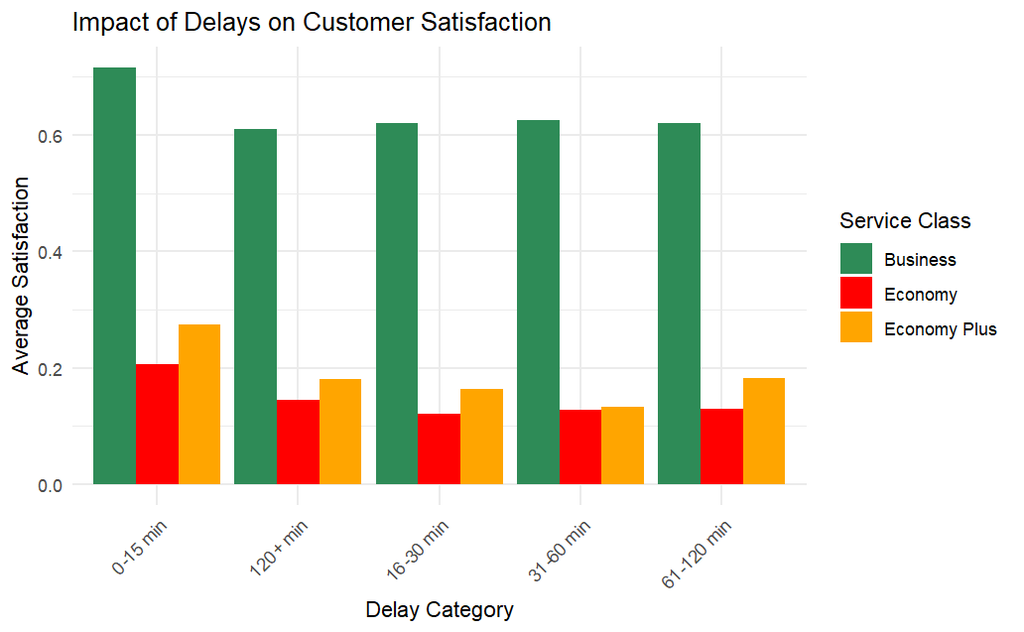

```r
# Create the Grouped Bar Chart
ggplot(data, aes(x = delay_category, y = avg_satisfaction, fill = class)) +
  geom_bar(stat = "identity", position = "dodge") +
  scale_fill_manual(values = c("Economy" = "red",
                               "Economy Plus" = "orange",
                               "Business" = "seagreen")) +  # Custom Colors
  labs(title = "Impact of Delays on Customer Satisfaction",
       x = "Delay Category",
       y = "Average Satisfaction",
       fill = "Service Class") +
  theme_minimal() +
  theme(axis.text.x = element_text(angle = 45, hjust = 1))  # Rotate X-axis labels for better readability
```

**Key Insights:**

**Satisfaction Trends by Delay:**

● **0-15 min:** Highest satisfaction across all service classes.  
● **16-30 min:** Noticeable drop in **Economy & Economy Plus** satisfaction.  
● **31-60 min:** **Economy** remains low, while **Business Class** stays stable.  
● **61-120 min:** **Economy** shows the most dissatisfaction, while **Business** retains relatively high ratings.

**Actionable Insights:**

● **Strengthen communication & service recovery** strategies for **Economy** passengers.  
● **Enhance in-flight experience** during delays, especially for **Economy & Economy Plus**.  
● **Maintain Business Class service consistency** to reinforce premium brand perception.

# **Final Insights & Business Impact Based on Overall Satisfaction**

## How Businesses Can Use This Data to Improve Customer Satisfactiont

1. **Enhance Economy Class Services:**  
   Improve **seat comfort, food quality,** and **in-flight entertainment** to reduce dissatisfaction (currently at **81.23%**).
2. **Improve First-Time Traveler Experience:**  
   Offer better **onboarding, check-in guidance,** and **first-time traveler perks** to boost satisfaction.
3. **Upgrade WiFi & Digital Services:**  
   Address **poor in-flight WiFi** and streamline the **online booking process** to enhance convenience.
4. **Optimize Gate Locations & Airport Navigation:**  
   Reduce **long walking distances** and improve **accessibility** for elderly and family travelers.
5. **Target Short-Haul Flights for Improvement:**  
   Enhance **food options**, streamline booking, and offer **better in-flight services** to improve satisfaction on short-haul flights.
6. **Strengthen Economy Passenger Experience During Delays:**  
   Provide better **communication, compensation,** and **in-flight amenities** during disruptions to improve retention and satisfaction.
7. **Personalize Offerings Based on Age Group Needs:**  
   Improve **accessibility for seniors (60+),** offer **family-friendly services** for children, and maintain quality for the **45-59 age group**.
8. **Refine Food & Beverage Options:**  
   Introduce **premium upgrades** and **dietary-specific choices** across all travel classes to address dissatisfaction.
9. **Leverage Business Traveler Loyalty:**  
   Maintain high service quality for **business travelers** to strengthen **retention** and **repeat bookings**.
10. **Use Data-Driven Personalization:**  
    Implement **AI-driven recommendations** to tailor services and offers based on **customer history and preferences**.

### **Key Analysis & Research Approach**

*This summary captures only the final insights, but I conducted deep research, statistical analysis, and created visualizations for a full understanding of customer satisfaction across age, gender, travel class, and travel distance, , ensuring quick understanding while the full analysis provides deeper correlations and patterns.*

# **Conclusion**

- The findings highlight **clear opportunities for improving airline services**, particularly in **Economy and Economy Plus**, where dissatisfaction is highest.
- Addressing key service gaps can **enhance customer satisfaction, increase retention, and strengthen brand loyalty**.
- Moving forward, a **data-driven approach** focused on **passenger experience, affordability, and convenience** will be essential for long-term success.  
  **Implementing these recommendations can lead to higher customer retention, increased bookings, and a competitive advantage** in the airline industry.